# tree_orderer2

hirgh815

Fist I want to clarify the difference between these two function I found:

## ape rotateConstr() and phytools minRotate()

The rotateConstr() function rotates internal nodes to find the closest possible match to the desired_order vector without altering the underlying tree topology (i.e., it doesn’t change who is related to whom, just how it’s visualized). The minRotate() is from phytools. It also leaves the topology unchanged. Instead of directly following the supplied ordering, it searches over allowable node rotations to minimize disagreement between the current tip order and the desired tip order.

The disagreement is measured by the number of pairwise inversions. For small tress they are equal, but these algorithm differ when we encounter cases where more than one way exists to rotate a tree without changing its evolutionary relationships, and the software must choose one arrangement.

```r
#install.packages("ape")
library(ape)
library(phytools)
# Create a random tree with 5 tips
set.seed(42)
my_tree <- rtree(5, tip.label = c("A", "B", "C", "D", "E"))

# Let's see the current tip order
my_tree$tip.label
```

```
## [1] "A" "B" "D" "C" "E"
```

```r
# Output is: "A" "B" "C" "D" "E" (but visual order depends on topology)

# Define your desired target order
desired_order <- c("E", "C", "A", "D", "B")

# Reorder the tree topology to match the constraint
reordered_tree_1 <- rotateConstr(my_tree, desired_order)
reordered_tree_2 <- minRotate(my_tree, desired_order)
```

```
## objective: 0
```

```
## objective: 0
## objective: 0
## objective: 0
```

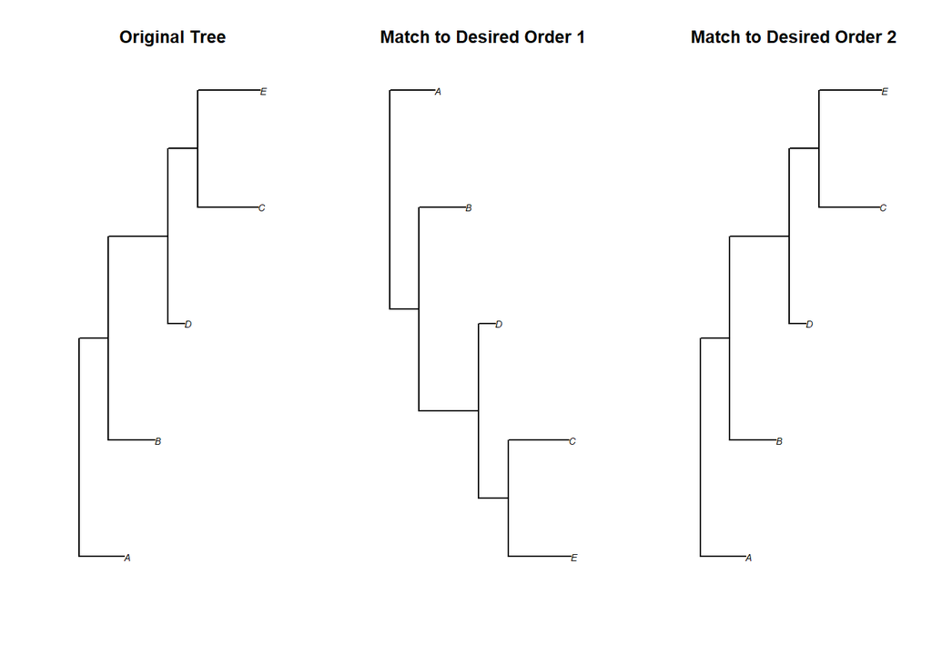

```r
# Check the new visual tip order
#reordered_tree$tip.label

par(mfrow = c(1, 3)) # Side-by-side plotting

# Original Tree
plot(my_tree, main = "Original Tree")

# Reordered Tree using ape
plot(reordered_tree_1, main = "Match to Desired Order 1")

# Reordered Tree using phytools
plot(reordered_tree_2, main = "Match to Desired Order 2")
```

```r
print(all.equal(reordered_tree_1,reordered_tree_2))
```

```
## [1] TRUE
```

## Solution 1

Originally I gave a complete ordering (desired_order) that was already known. Now, the ordering itself has to be inferred from the trait values, while respecting the topology of the tree. The PCA algorithm can be a heuristic for generating such an ordering but it is also very approximate.

```r
library(ape)
library(phytools)

traits <- matrix(runif(30, 0, 5), nrow = 5, dimnames = list(my_tree$tip.label))

pc <- prcomp(traits, scale.=TRUE)

score <- pc$x[,1]

desired_order <- names(sort(score))

desired_order
```

```
## [1] "B" "C" "D" "E" "A"
```

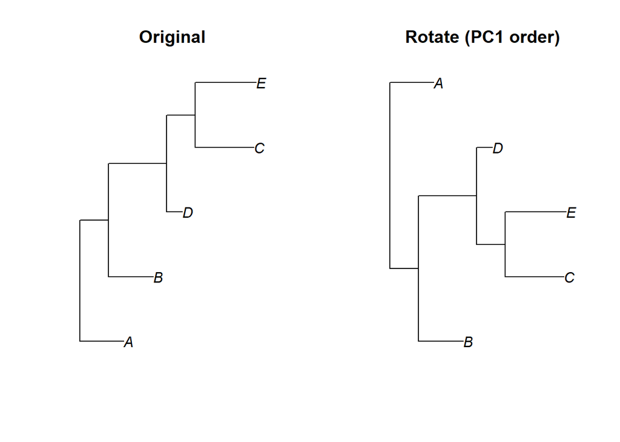

```r
tree_Rotate <- rotateConstr(my_tree, desired_order) # or minRotate(my_tree, desired_order)

par(mfrow=c(1,2))

plot(my_tree,
     main="Original")

plot(tree_Rotate,
     main="Rotate (PC1 order)")
```

## Solution 2

Another robust mathematical approach is seriation. This treats the problem of ordering the tips as a Traveling Salesperson Problem (TSP), find the shortest path (1D order again) that visits every single tip’s trait vector exactly once, minimizing the step-by-step distance.

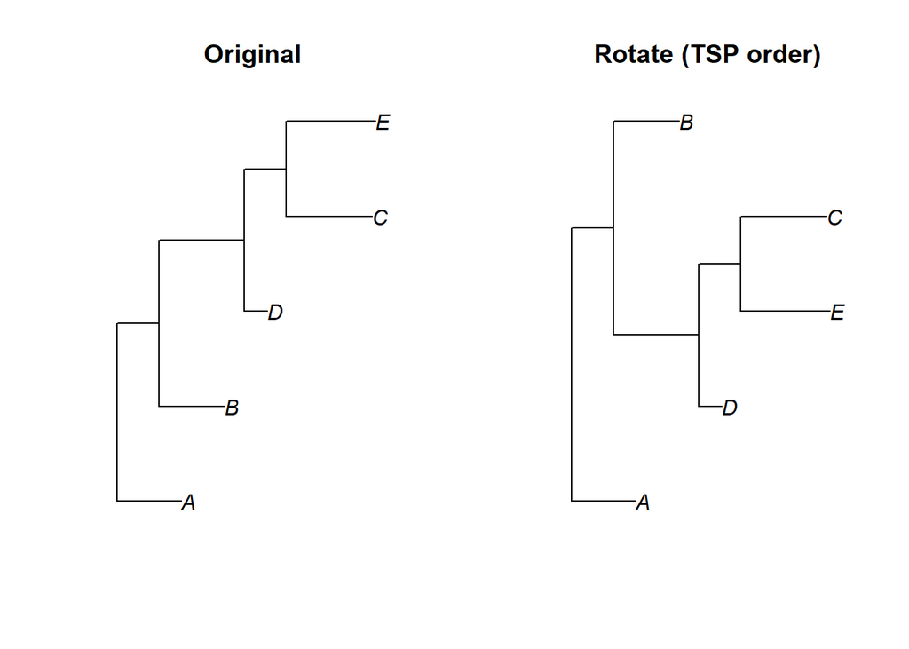

```r
# install.packages("seriation")
library(ape)
library(seriation)

# Simulate a 3D trait matrix
dist_matrix <- dist(traits)

# Use TSP solver to find the optimal 1D path minimizing total step-wise distance
tsp_sol <- seriate(dist_matrix, method = "TSP")
suggested_order <- get_order(tsp_sol) # Extract the 1D permutation

# Map the indices back to tip labels
target_sequence <- labels(dist_matrix)[suggested_order]

# Rotate the tree to match this optimal TSP sequence
optimized_tree <- rotateConstr(my_tree, target_sequence) # or minRotate(my_tree, target_sequence)

par(mfrow=c(1,2))

plot(my_tree,
     main="Original")

plot(optimized_tree,
     main="Rotate (TSP order)")
```

## Solution 3

For such a small tree I can explore everything:

```r
## Cost function

# ordering_cost <- function(order, traits){
#
#     X <- traits[order,,drop=FALSE]
#
#     sum(sqrt(rowSums((X[-1,]-X[-nrow(X),])^2)))
#
# }

# 1. Get plot order safely via .PlotPhyloEnv
get_plot_order <- function(tree){
    oldpar <- par(no.readonly = TRUE)
    on.exit(par(oldpar))

    plot(tree, plot = FALSE)
    pp <- get("last_plot.phylo", envir = .PlotPhyloEnv)
    n <- length(tree$tip.label)

    # Order tips based on their vertical positioning (yy) in the plot
    tree$tip.label[order(pp$yy[1:n])]
}

# 2. Calculate continuous trait transition distance along the tip profile
trait_cost <- function(tree, traits){
    ord <- get_plot_order(tree)
    X <- traits[ord, , drop = FALSE]

    sum(
        sqrt(
            rowSums((X[-1, , drop = FALSE] - X[-nrow(X), , drop = FALSE])^2)
        )
    )
}

# 3. Generate every valid topological rotation using a Breadth-First Search (BFS)
all_rotations <- function(tree){
    Ntip <- length(tree$tip.label)
    internal <- (Ntip + 1):(Ntip + tree$Nnode)

    # Initialize queue and visited set using Newick format strings
    initial_key <- write.tree(tree)
    seen <- initial_key
    queue <- list(tree)
    all_trees <- list(tree)

    head_idx <- 1
    while(head_idx <= length(queue)){
        current_tree <- queue[[head_idx]]
        head_idx <- head_idx + 1

        for(node in internal){
            # Use ape::rotate to flip the chosen internal node
            tmp <- rotate(current_tree, node)
            key <- write.tree(tmp)

            if(!(key %in% seen)){
                seen <- c(seen, key)
                queue[[length(queue) + 1]] <- tmp
                all_trees[[length(all_trees) + 1]] <- tmp
            }
        }
    }
    return(all_trees)
}

# 4. Evaluate every single unique rotation configuration
trees <- all_rotations(my_tree)
costs <- numeric(length(trees))
orders <- vector("list", length(trees))

for(i in seq_along(trees)){
    # FIX: Pass the tree object to trait_cost, not the raw text vector of labels
    costs[i] <- trait_cost(trees[[i]], traits)
    orders[[i]] <- get_plot_order(trees[[i]])
}
```

```r
# Find the global minimum configuration
best <- which.min(costs)
best_tree <- trees[[best]]
best_order <- orders[[best]]
best_cost <- costs[[best]]

# Output results
cat("Best order:\n")
```

```
## Best order:
```

```r
print(best_order)
```

```
## [1] "B" "C" "E" "D" "A"
```

```r
cat("\nCost =", best_cost, "\n")
```

```
##
## Cost = 19.71716
```

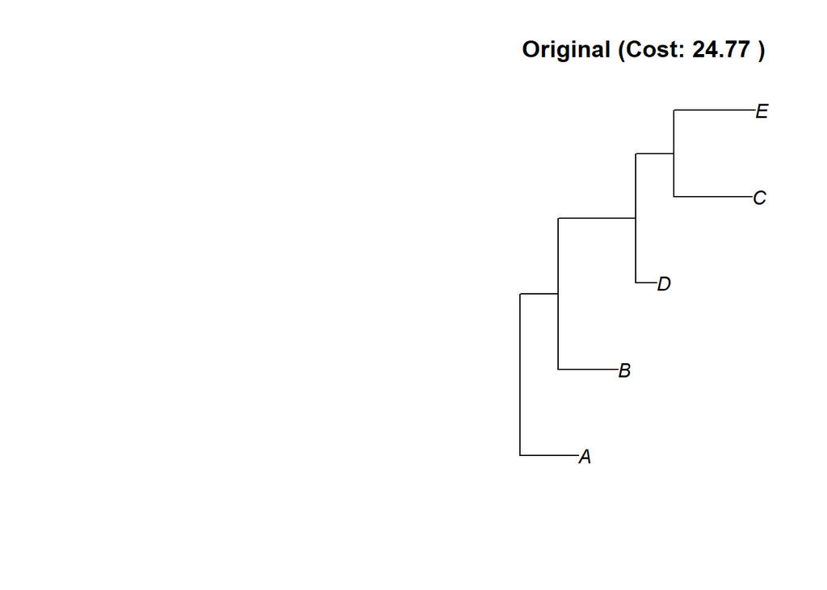

```r
# Layout comparison plots
par(mfrow = c(1, 2))
plot(my_tree, main = paste("Original (Cost:", round(trait_cost(my_tree, traits), 2), ")"))
```

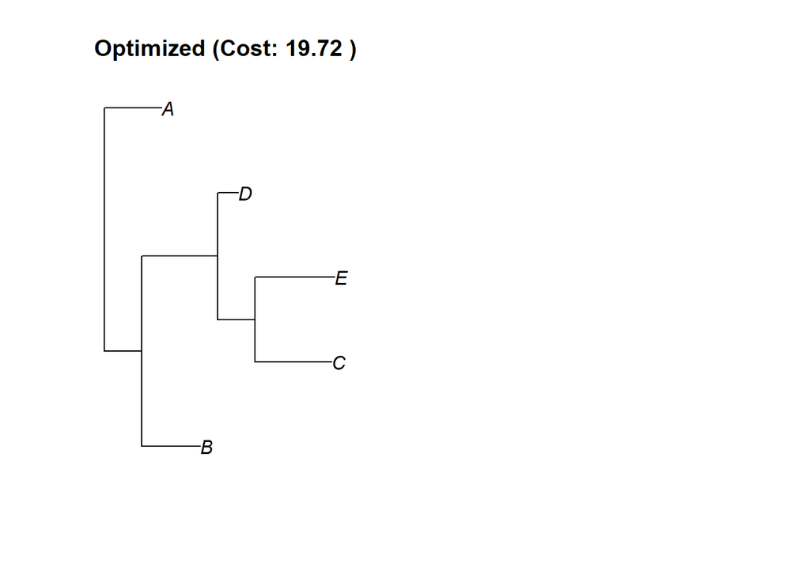

```r
plot(best_tree, main = paste("Optimized (Cost:", round(best_cost, 2), ")"))
```

## solution 4

For larger trees (e.g., 50–1000 tips), the brute-force enumeration above becomes infeasible. So instead I use meta-heuristic. Practical approach is to Start from the current tree embedding. Randomly rotate internal nodes (swap child branches). Accept better solutions always; worse solutions with probability $p=exp(-\frac{\Delta}{T})$ where T decreases over time (simulated annealing). Also Stop early if no improvement occurs for many iterations, temperature becomes very small, or maximum iterations reached.

```r
set.seed(42)

my_tree <- rtree(
    100,
    tip.label=paste0("Tip",1:100)
)

traits <- matrix(
    runif(100*6,0,5),
    nrow=100,
    dimnames=list(my_tree$tip.label,
                  paste0("Trait",1:6))
)



# Cost function


# get_plot_order <- function(tree){
#
#     oldpar <- par(no.readonly = TRUE)
#
#     on.exit(par(oldpar))
#
#     plot(
#         tree,
#         plot=FALSE
#     )
#
#     pp <- get(
#         "last_plot.phylo",
#         envir=.PlotPhyloEnv
#     )
#
#     n <- length(tree$tip.label)
#
#     tree$tip.label[
#         order(pp$yy[1:n])
#     ]
# }
#
# trait_cost <- function(tree, traits){
#
#     ord <- get_plot_order(tree)
#
#     X <- traits[ord,,drop=FALSE]
#
#     sum(
#         sqrt(
#             rowSums(
#                 (X[-1,]-X[-nrow(X),])^2
#             )
#         )
#     )
# }

# Fast tree tip order (no plotting)


get_plot_order <- function(tree){

    n <- length(tree$tip.label)

    # children of each internal node
    children <- split(
        tree$edge[,2],
        tree$edge[,1]
    )

    root <- setdiff(
        tree$edge[,1],
        tree$edge[,2]
    )[1]

    # recursive depth-first traversal
    traverse <- function(node){

        # tip
        if(node <= n){
            return(node)
        }

        unlist(
            lapply(
                children[[as.character(node)]],
                traverse
            )
        )
    }

    idx <- traverse(root)

    tree$tip.label[idx]
}


trait_cost <- function(tree, traits){

    ord <- get_plot_order(tree)

    X <- traits[ord,,drop=FALSE]

    sum(
        sqrt(
            rowSums(
                (X[-1,]-X[-nrow(X),])^2
            )
        )
    )

}


# Random rotation of one internal node


random_rotate <- function(tree){

    Ntip <- length(tree$tip.label)

    internal_nodes <- (Ntip+1):(Ntip+tree$Nnode)

    node <- sample(internal_nodes,1)

    tree2 <- tree

    children <- which(tree2$edge[,1]==node)

    if(length(children)==2){

        tree2$edge[children,2] <-
            rev(tree2$edge[children,2])

    }

    tree2

}




# Simulated annealing optimizer


anneal_tree_order <- function(
        tree,
        traits,
        max_iter=100000,
        temperature=1,
        cooling=0.99995,
        patience=5000
){

    current_tree <- tree

    current_cost <- trait_cost(
        current_tree,
        traits
    )

    cat(
    "Starting cost:",
    current_cost,
    "\n"
    )

    best_tree <- current_tree

    best_cost <- current_cost

    no_improve <- 0

    for(iter in 1:max_iter){

        candidate <- random_rotate(
            current_tree
        )

        candidate_cost <- trait_cost(
            candidate,
            traits
        )

        delta <- candidate_cost-current_cost

        # Metropolis acceptance rule

        accept <- FALSE

        if(delta < 0){

            accept <- TRUE

        } else {

            probability <- exp(
                -delta/temperature
            )

            if(runif(1)<probability){
                accept <- TRUE
            }

        }

        if(accept){

            current_tree <- candidate

            current_cost <- candidate_cost

        }

        # Save best

        if(current_cost < best_cost){

            best_tree <- current_tree

            best_cost <- current_cost

            no_improve <- 0

        } else {

            no_improve <- no_improve + 1

        }

        # Cooling

        temperature <- temperature * cooling

        # Early stopping

        if(no_improve >= patience){

            message(
                "Stopped early at iteration ",
                iter
            )

            break

        }

        if(temperature < 1e-8){

            message(
                "Temperature exhausted"
            )

            break

        }

        if(iter %% 1000 == 0){

            message(
                "Iteration ",
                iter,
                " Best cost = ",
                best_cost
            )

        }

    }

    list(
        tree=best_tree,
        cost=best_cost,
        iterations=iter
    )

}




# Run optimization


result <- anneal_tree_order(
    my_tree,
    traits,
    max_iter=200000,
    temperature=10,
    cooling=0.99997,
    patience=10000
)
```

```
## Starting cost: 480.1262
```

```
## Iteration 1000 Best cost = 438.634129888815
```

```
## Iteration 2000 Best cost = 437.861031074048
```

```
## Iteration 3000 Best cost = 437.861031074048
```

```
## Iteration 4000 Best cost = 437.861031074048
```

```
## Iteration 5000 Best cost = 437.861031074048
```

```
## Iteration 6000 Best cost = 435.646402031118
```

```
## Iteration 7000 Best cost = 435.274741688399
```

```
## Iteration 8000 Best cost = 435.274741688399
```

```
## Iteration 9000 Best cost = 432.933238188231
```

```
## Iteration 10000 Best cost = 432.933238188231
```

```
## Iteration 11000 Best cost = 432.933238188231
```

```
## Iteration 12000 Best cost = 432.933238188231
```

```
## Iteration 13000 Best cost = 432.933238188231
```

```
## Iteration 14000 Best cost = 432.933238188231
```

```
## Iteration 15000 Best cost = 430.737545040096
```

```
## Iteration 16000 Best cost = 430.737545040096
```

```
## Iteration 17000 Best cost = 430.737545040096
```

```
## Iteration 18000 Best cost = 430.737545040096
```

```
## Iteration 19000 Best cost = 430.737545040096
```

```
## Iteration 20000 Best cost = 430.737545040096
```

```
## Iteration 21000 Best cost = 430.737545040096
```

```
## Iteration 22000 Best cost = 430.737545040096
```

```
## Iteration 23000 Best cost = 430.737545040096
```

```
## Iteration 24000 Best cost = 430.737545040096
```

```
## Iteration 25000 Best cost = 425.112838658089
```

```
## Iteration 26000 Best cost = 425.112838658089
```

```
## Iteration 27000 Best cost = 425.112838658089
```

```
## Iteration 28000 Best cost = 425.112838658089
```

```
## Iteration 29000 Best cost = 425.112838658089
```

```
## Iteration 30000 Best cost = 425.112838658089
```

```
## Iteration 31000 Best cost = 425.112838658089
```

```
## Iteration 32000 Best cost = 425.112838658089
```

```
## Iteration 33000 Best cost = 425.112838658089
```

```
## Iteration 34000 Best cost = 425.112838658089
```

```
## Stopped early at iteration 34099
```

```r
# Results


optimized_tree <- result$tree

init_cost <- trait_cost(my_tree,traits)
cat(
    "Initial cost:",
    init_cost,
    "\n"
)
```

```
## Initial cost: 480.1262
```

```r
cat(
    "Final cost:",
    result$cost,
    "\n"
)
```

```
## Final cost: 425.1128
```

```r
cat(
    "Iterations:",
    result$iterations,
    "\n"
)
```

```
## Iterations: 34099
```

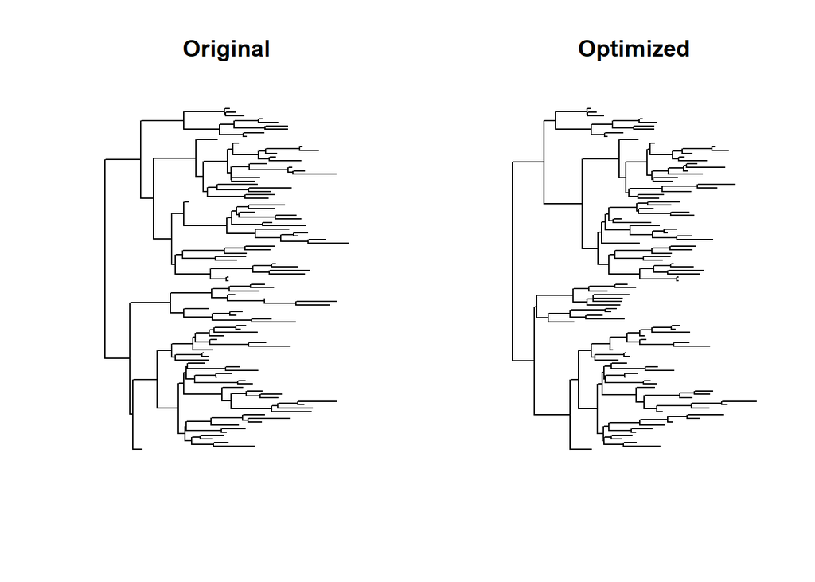

```r
# Plot example


par(mfrow=c(1,2))

plot(my_tree,
     show.tip.label=FALSE,
     main="Original")

plot(optimized_tree,
     show.tip.label=FALSE,
     main="Optimized")
```

## Solution 5

```r
# Simulate tree and traits


set.seed(42)

nTips <- 500

my_tree <- rtree(
    nTips,
    tip.label=paste0("Tip",1:nTips)
)


traits <- matrix(
    runif(nTips*10,0,5),
    nrow=nTips,
    dimnames=list(
        my_tree$tip.label,
        paste0("Trait",1:10)
    )
)



############################################################
# Objective function


# Fast tree tip order (no plotting, I tried plotting it took decades)


get_plot_order <- function(tree){

    n <- length(tree$tip.label)

    # children of each internal node
    children <- split(
        tree$edge[,2],
        tree$edge[,1]
    )

    root <- setdiff(
        tree$edge[,1],
        tree$edge[,2]
    )[1]

    # recursive depth-first traversal
    traverse <- function(node){

        # tip
        if(node <= n){
            return(node)
        }

        unlist(
            lapply(
                children[[as.character(node)]],
                traverse
            )
        )
    }

    idx <- traverse(root)

    tree$tip.label[idx]
}


trait_cost <- function(tree, traits){

    ord <- get_plot_order(tree)

    X <- traits[ord,,drop=FALSE]

    sum(
        sqrt(
            rowSums(
                (X[-1,]-X[-nrow(X),])^2
            )
        )
    )

}




# Random rotation


random_rotate <- function(tree){

    Ntip <- length(tree$tip.label)

    node <- sample(
        (Ntip+1):(Ntip+tree$Nnode),
        1
    )

    rows <- which(tree$edge[,1]==node)

    if(length(rows)==2){

        tree$edge[rows,2] <-
            rev(tree$edge[rows,2])

    }

    tree
}




# Annealing


anneal_tree <- function(
        tree,
        traits,
        max_iter=100000,
        temperature=10,
        cooling=.99995,
        patience=5000
){

    current <- tree

    current_cost <- trait_cost(
        current,
        traits
    )

    cat(
    "Starting cost:",
    current_cost,
    "\n"
    )

    best <- current
    best_cost <- current_cost

    no_change <- 0

    for(i in 1:max_iter){

        candidate <- random_rotate(current)

        candidate_cost <- trait_cost(
            candidate,
            traits
        )

        delta <- candidate_cost-current_cost

        if(
            delta < 0 ||
            runif(1)<exp(-delta/temperature)
        ){

            current <- candidate
            current_cost <- candidate_cost

        }

        if(current_cost < best_cost){

            best <- current
            best_cost <- current_cost

            no_change <- 0

        } else {

            no_change <- no_change+1

        }

        temperature <- temperature*cooling

        if(no_change > patience){

            return(
                list(
                    tree=best,
                    cost=best_cost,
                    iterations=i
                )
            )

        }

    }

    list(
        tree=best,
        cost=best_cost,
        iterations=max_iter
    )

}




############################################################
# METHOD 1:
# Random starting layout
############################################################

cat(
    "Initial cost:",
    trait_cost(my_tree,traits),
    "\n"
)
```

```
## Initial cost: 3186.101
```

```r
cat("\nRandom initialization\n")
```

```
##
## Random initialization
```

```r
random_order <- sample(my_tree$tip.label)

random_tree <- rotateConstr(
    my_tree,
    random_order
)

cat(
    "Initial random cost:",
    trait_cost(random_tree, traits),
    "\n"
)
```

```
## Initial random cost: 3223.377
```

```r
start1 <- Sys.time()



random_result <- anneal_tree(
    random_tree,
    traits
)
```

```
## Starting cost: 3223.377
```

```r
time1 <- Sys.time()-start1



############################################################
# METHOD 2:
# PCA initialization
############################################################

cat("\nPCA initialization\n")
```

```
##
## PCA initialization
```

```r
############################################################
# PCA scores
############################################################

pc <- prcomp(
    traits,
    scale.=TRUE
)


pc_order <- rownames(
    traits
)[
    order(pc$x[,1])
]


############################################################
# Rotate tree to PCA order
############################################################

pca_tree <- rotateConstr(
    my_tree,
    pc_order
)





cat(
    "Initial PCA cost:",
    trait_cost(pca_tree,traits),
    "\n"
)
```

```
## Initial PCA cost: 3227.915
```

```r
start2 <- Sys.time()

pca_result <- anneal_tree(
    pca_tree,
    traits
)
```

```
## Starting cost: 3227.915
```

```r
time2 <- Sys.time()-start2


############################################################
# METHOD 3:
# PCA + Greedy + Annealing
############################################################

cat("\nGreedy initialization\n")
```

```
##
## Greedy initialization
```

```r
# Greedy local optimization

greedy_optimize <- function(tree, traits, max_passes = 100){

    current <- tree
    current_cost <- trait_cost(current, traits)

    Ntip <- length(tree$tip.label)

    internal_nodes <- (Ntip + 1):(Ntip + tree$Nnode)

    pass <- 1

    repeat{

        improved <- FALSE

        for(node in internal_nodes){

            rows <- which(current$edge[,1] == node)

            if(length(rows) != 2)
                next

            candidate <- current

            candidate$edge[rows,2] <-
                rev(candidate$edge[rows,2])

            candidate_cost <- trait_cost(
                candidate,
                traits
            )

            if(candidate_cost < current_cost){

                current <- candidate
                current_cost <- candidate_cost
                improved <- TRUE

            }

        }

        cat(
            "Greedy pass",
            pass,
            "cost:",
            current_cost,
            "\n"
        )

        pass <- pass + 1

        if(!improved || pass > max_passes)
            break

    }

    list(
        tree = current,
        cost = current_cost,
        passes = pass - 1
    )

}

greedy_start <- greedy_optimize(
    my_tree,
    traits
)
```

```
## Greedy pass 1 cost: 2961.325
## Greedy pass 2 cost: 2923.119
## Greedy pass 3 cost: 2917.947
## Greedy pass 4 cost: 2917.947
```

```r
greedy_tree <- greedy_start$tree

cat(
    "Initial greedy cost:",
    greedy_start$cost,
    "\n"
)
```

```
## Initial greedy cost: 2917.947
```

```r
start3 <- Sys.time()

greedy_result <- anneal_tree(
    greedy_tree,
    traits
)
```

```
## Starting cost: 2917.947
```

```r
time3 <- Sys.time()-start3

############################################################
# Compare
############################################################

results <- data.frame(

    Method=c(
        "Random start",
        "PCA + rotateConstr",
        "Greedy + Annealing"
    ),

    Initial_cost=c(
        trait_cost(random_tree, traits),
        trait_cost(pca_tree, traits),
        greedy_start$cost
    ),

    Final_cost=c(
        random_result$cost,
        pca_result$cost,
        greedy_result$cost
    ),

    Iterations=c(
        random_result$iterations,
        pca_result$iterations,
        greedy_result$iterations
    ),

    Time_seconds=c(
        as.numeric(time1),
        as.numeric(time2),
        as.numeric(time3)
    )

)

print(results)
```

```
##               Method Initial_cost Final_cost Iterations Time_seconds
## 1       Random start     3223.377   3113.805       6385     1.024817
## 2 PCA + rotateConstr     3227.915   3095.365      11396     1.871493
## 3 Greedy + Annealing     2917.947   2917.947       5001    49.057805
```